# Household Demography model: sensitivity analysis

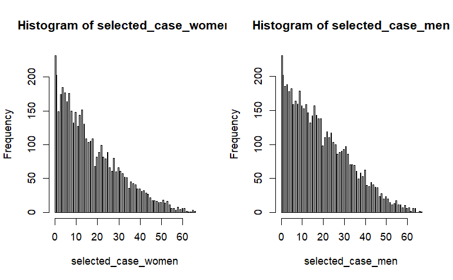

```r
layout(matrix(1:2, nrow = 1))
hist(selected_case_women, breaks = 101)
hist(selected_case_men, breaks = 101)
```

```r
# Put data into long format
age_struct_df <- tibble(
  age = c(selected_case_men, selected_case_women),
  sex = c(rep("Male", length(selected_case_men)),
          rep("Female", length(selected_case_women)))
)

# Bin ages into groups (5-year bins, adjust as needed)
age_struct_df <- age_struct_df |>
  mutate(age_group = cut(age, breaks = seq(0, 95, 5), right = FALSE))

# Summarize counts per age group and sex
age_struct_df_summary <- age_struct_df |>
  count(sex, age_group)

# For pyramid: make men negative
age_struct_df_summary <- age_struct_df_summary |>
  mutate(count = ifelse(sex == "Male", -n, n))
```

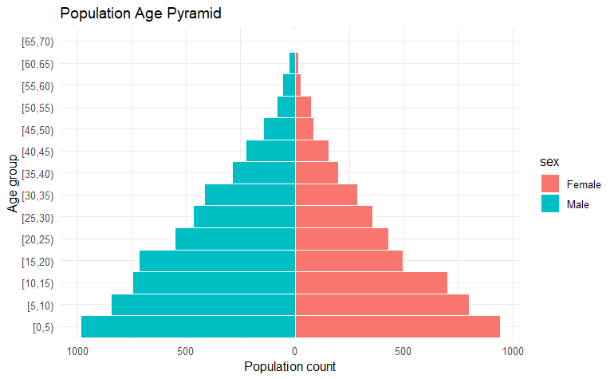

```r
ggplot(age_struct_df_summary, aes(x = age_group, y = count, fill = sex)) +
  geom_col(width = 1, color = "white") +
  coord_flip() +
  scale_y_continuous(labels = abs) +
  labs(
    title = "Population Age Pyramid",
    x = "Age group",
    y = "Population count"
  ) +
  theme_minimal()
```

Calculate the Peristera-Kostaki parameter ranges associated to survival:

```r
compute_param_envelope <- function(param_df, low=0.025, high=0.975){
  apply(param_df, 2, quantile, probs = c(low, high), na.rm=TRUE) %>%
    t() %>% as.data.frame() #%>% rename(lower = `2.5%`, upper = `97.5%`)
}
params_names <- gsub("-", ".", names(sobol_parameter_ranges)[7:19])
compute_param_envelope(endStates %>% filter(survival != "extinction") %>% select(params_names))
```

|  | 2.5% | 97.5% |
| --- | --- | --- |
| cdmlt.level | 2.00000000 | 24.0000000 |
| c1.fert | 0.01293335 | 0.4875549 |
| mu.fert | 15.38067627 | 29.6193237 |
| sigma1.fert | 1.22840576 | 9.7671997 |
| sigma2.fert | 5.38067627 | 19.6193237 |
| c1.women | 0.02537842 | 0.9746216 |
| mu.women | 15.64666748 | 39.3655396 |
| sigma1.women | 1.48218994 | 19.5178101 |
| sigma2.women | 1.48218994 | 19.5178101 |
| c1.men | 0.02537842 | 0.9746216 |

[output cut: 3 more lines]

```r
params_indexes <- c(9, 12, 14:17, 20:27, 47:50)
param_names <- names(endStates)[params_indexes]

endStates_long <- endStates %>%
  pivot_longer(cols = all_of(param_names)) %>%
  mutate(name = factor(name, levels = param_names))  # Preserve order
```

```r
source("library/bifurcationPlot.R")

plotName = paste0(plotDirectory, "sobol_bifurcationPlot.png")

plotScale = 10

png(plotName,
    width = 150 * plotScale, height = 80 * plotScale)

ggplot(data = endStates_long, aes(x = value, y = totalIndividuals)) +
  geom_point(alpha = 0.5) +
  geom_smooth(method = "glm") +
  facet_wrap(vars(name), ncol = 6, scales = "free_x") +
  theme(
    strip.text = element_text(size = 1.2 * plotScale)
  )

dev.off()
```

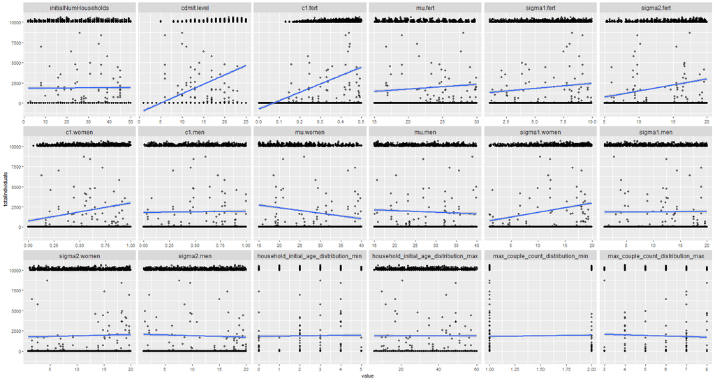

```r
knitr::include_graphics(plotName)
```

Train a Random Forest model to assess parameter importance:

```r
endStates_for_rf <- endStates[,c(params_indexes, 29)]

# Train Random Forest to predict simulation output
set.seed(123)
rf_model <- randomForest(totalIndividuals ~ ., data = endStates_for_rf, importance = TRUE, ntree = 500)

# Print model summary
print(rf_model)
```

```
Call:
 randomForest(formula = totalIndividuals ~ ., data = endStates_for_rf,      importance = TRUE, ntree = 500)
               Type of random forest: regression
                     Number of trees: 500
No. of variables tried at each split: 6

          Mean of squared residuals: 862575.1
                    % Var explained: 94.37
```

Extract importance values and print as table:

```r
# Extract importance values
importance_values <- importance(rf_model)

# Convert to a data frame
importance_df <- data.frame(Parameter = rownames(importance_values),
                            MDA = importance_values[, 1],
                            MDG = importance_values[, 2])

# Print importance scores
print(importance_df)
```

|  | Parameter | MDA | MDG |
| --- | --- | --- | --- |
| initialNumHouseholds | initialNumHouseholds | 42.46312 | 1614611679 |
| cdmlt.level | cdmlt.level | 202.84690 | 21946305357 |
| c1.fert | c1.fert | 172.38572 | 21897671534 |
| mu.fert | mu.fert | 34.14349 | 3219252436 |
| sigma1.fert | sigma1.fert | 37.61951 | 2590749077 |
| sigma2.fert | sigma2.fert | 69.18684 | 6876720718 |
| c1.women | c1.women | 81.71252 | 7168994436 |
| c1.men | c1.men | 44.63662 | 1942890368 |
| mu.women | mu.women | 61.39408 | 5179194426 |
| mu.men | mu.men | 39.68097 | 2387393594 |

[output cut: 8 more lines]

Plot feature importance colouring parameters by domain (general, mortality, fertility, nuptiality):

```r
source("library/variableImportancePlot.R")

plotName = paste0(plotDirectory, "sobol_variableImportancePlot.png")

color_variable_map <- rev(c("#0000a2",
                        "#bc272d",
                        rep("#e9c716", 4),
                        rep("#50ad9f", 8),
                        rep("#0000a2", 4)
))

# png
png(filename = plotName, width = 129, height = 168, units="mm", res=1200)
variableImportancePlot(rf_model, plot_scale = 0.5, color_variable_map = color_variable_map, range_standardised = TRUE)
dev.off()
```

```r
knitr::include_graphics(plotName)
```

[figure not shown]

### Initial household population

This parameter has slight positive effect on population survival:

```r
summary(endStates$initialNumHouseholds[endStates$totalIndividuals == 0])
```

```
   Min. 1st Qu.  Median    Mean 3rd Qu.    Max.
   2.00   14.00   26.00   25.89   38.00   50.00
```

```r
summary(endStates$initialNumHouseholds[endStates$totalIndividuals > 0])
```

```
   Min. 1st Qu.  Median    Mean 3rd Qu.    Max.
   2.00   15.00   27.00   26.41   39.00   50.00
```

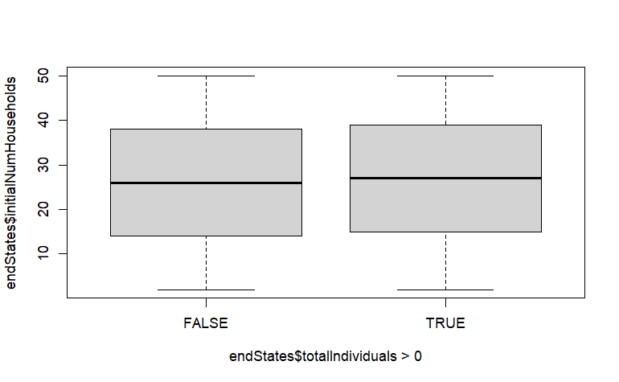

```r
boxplot(endStates$initialNumHouseholds ~ (endStates$totalIndividuals > 0))
```

### Mortality factors

Coale-Demeny Life Tables Model level parameter has great effect:

```r
summary(endStates$cdmlt.level[endStates$totalIndividuals == 0])
```

```
   Min. 1st Qu.  Median    Mean 3rd Qu.    Max.
   1.00    6.00   11.00   11.59   17.00   25.00
```

```r
summary(endStates$cdmlt.level[endStates$totalIndividuals > 0])
```

```
   Min. 1st Qu.  Median    Mean 3rd Qu.    Max.
   5.00   16.00   19.00   18.77   22.00   25.00
```

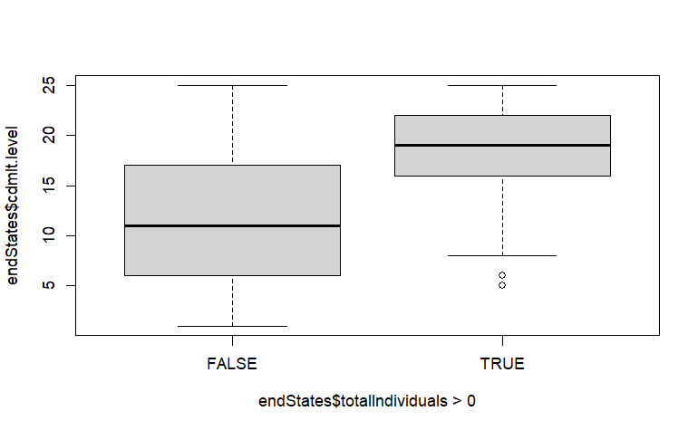

```r
boxplot(endStates$cdmlt.level ~ (endStates$totalIndividuals > 0))
```

```r
table(endStates$coale.demeny.region, endStates$totalIndividuals > 0)
```

```
        FALSE TRUE
  south  4827 1173
```

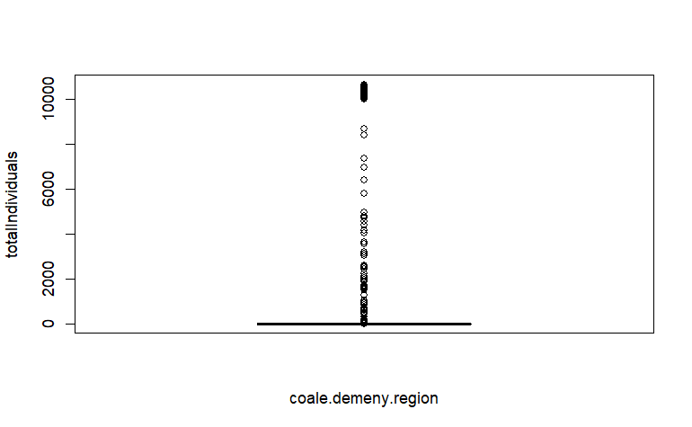

```r
boxplot(data = endStates, totalIndividuals ~ coale.demeny.region)
```

### Fertility factors

```r
layout(matrix(1:4, nrow = 2, byrow = T))
boxplot(endStates$c1.fert ~ (endStates$totalIndividuals > 0), main = "c1.fert")
boxplot(endStates$mu.fert ~ (endStates$totalIndividuals > 0), main = "mu.fert")
```

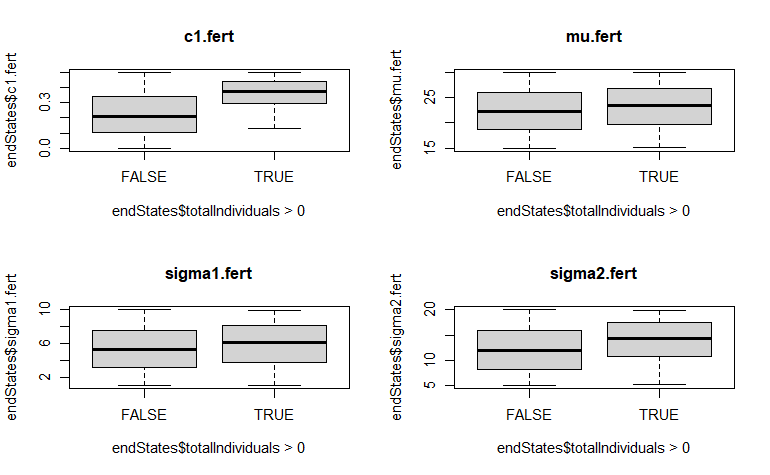

```r
boxplot(endStates$sigma1.fert ~ (endStates$totalIndividuals > 0), main = "sigma1.fert")
boxplot(endStates$sigma2.fert ~ (endStates$totalIndividuals > 0), main = "sigma2.fert")
```

### Nuptiality factors

Residential rule showing no clear effect:

```r
table(endStates$residence.rule, endStates$totalIndividuals > 0)
```

```
                         FALSE TRUE
  matrilocal-matrilineal  4827 1173
```

The effect of the acceptable kinship degree is also unclear:

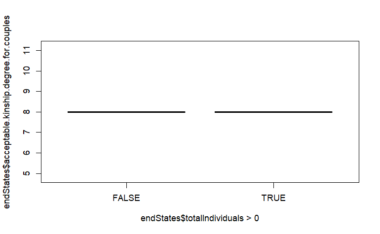

```r
boxplot(endStates$acceptable.kinship.degree.for.couples ~ (endStates$totalIndividuals > 0))
```

```r
layout(matrix(1:8, nrow = 2, byrow = T))
boxplot(endStates$c1.women ~ (endStates$totalIndividuals > 0), main = "c1.women")
boxplot(endStates$mu.women ~ (endStates$totalIndividuals > 0), main = "mu.women")
```

```r
boxplot(endStates$sigma1.women ~ (endStates$totalIndividuals > 0), main = "sigma1.women")
boxplot(endStates$sigma2.women ~ (endStates$totalIndividuals > 0), main = "sigma2.women")
```

```r
boxplot(endStates$c1.men ~ (endStates$totalIndividuals > 0), main = "c1.men")
boxplot(endStates$mu.men ~ (endStates$totalIndividuals > 0), main = "mu.men")
```

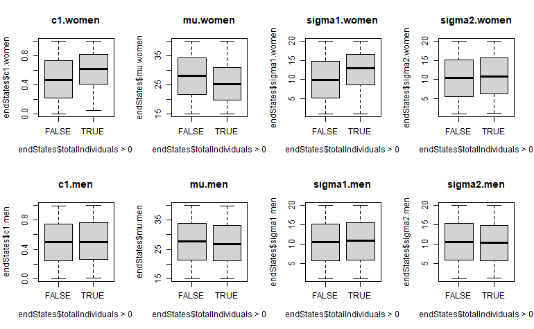

```r
boxplot(endStates$sigma1.men ~ (endStates$totalIndividuals > 0), main = "sigma1.men")
boxplot(endStates$sigma2.men ~ (endStates$totalIndividuals > 0), main = "sigma2.men")
```

## Timing of survival

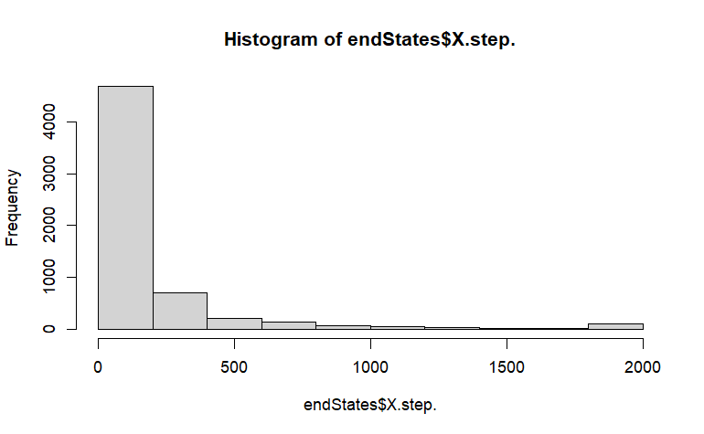

```r
hist(endStates$X.step.)
```

```r
table(endStates$X.step. > 0)
```

```
FALSE  TRUE
    1  5999
```

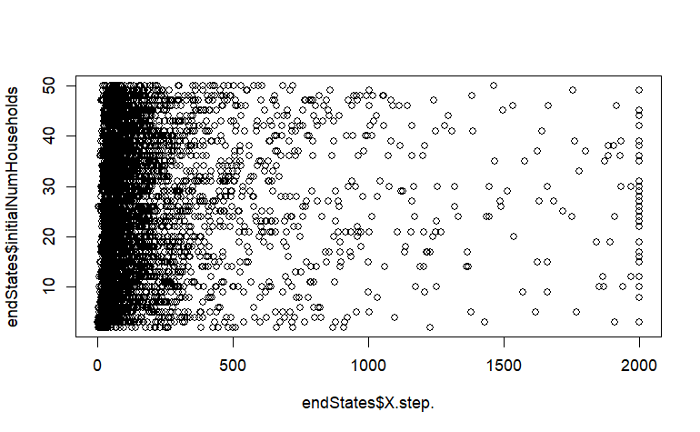

```r
plot(endStates$initialNumHouseholds ~ endStates$X.step.)
```

### With patrilineal rule

Loading simulation experiments’ end states:

```r
endStates_patri <- read.csv("simdata/v1.1/householdDemography v.1.1 - kinship tabu for new couples exp-endstates-table_patri.csv", skip = 6)
```

Process parameters in list format in NetLogo:

```r
extract_values_from_NetLogo_list <- function(char_vector) {
  # Remove brackets and split each string into two parts
  split_values <- gsub("\\[|\\]", "", char_vector) |>
    strsplit(" ")

  # Convert to numeric vectors
  first_values <- sapply(split_values, function(x) as.numeric(x[1]))
  second_values <- sapply(split_values, function(x) as.numeric(x[2]))

  # Return as a named list
  list(
    first = first_values,
    second = second_values
  )
}

household_initial_age_distribution_range <- extract_values_from_NetLogo_list(endStates_patri$householdInitialAgeDistribution)
max_couple_count_distribution_range <- extract_values_from_NetLogo_list(endStates_patri$maxCoupleCountDistribution)

endStates_patri <- cbind(
  endStates_patri,
  household_initial_age_distribution_min = household_initial_age_distribution_range[[1]],
  household_initial_age_distribution_max = household_initial_age_distribution_range[[2]],
  max_couple_count_distribution_min = max_couple_count_distribution_range[[1]],
  max_couple_count_distribution_max = max_couple_count_distribution_range[[2]]
)
```

[output not shown]

Categorise end states according to whether populations get extinct, survive and/or grow within the maximum number of simulation steps (`max-iterations`).

Visualise `totalIndividuals`:

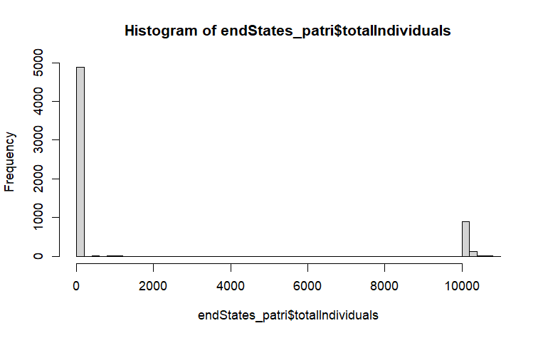

```r
hist(endStates_patri$totalIndividuals, breaks = 50)
```

create new categorical variable:

```r
max_population = 10000 # population size used in NetLogo as a stop condition when there is considerable growth
endStates_patri$survival <- ifelse(endStates_patri$totalIndividuals > 0, "survival", "extinction")
endStates_patri$survival <- paste(endStates_patri$survival, ifelse(endStates_patri$totalIndividuals > max_population, "with growth", ""))
```

```r
table(endStates_patri$survival)
```

```
         extinction             survival  survival with growth
                4856                   99                 1045
```

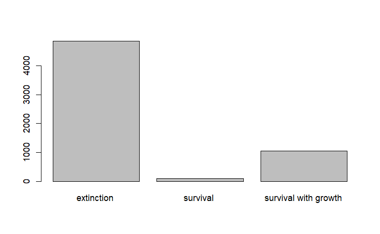

```r
barplot(table(endStates_patri$survival))
```

```r
extract_age_structure <- function(char_value) {
  split_values <- gsub("\\[|\\]", "", char_value) |>
    strsplit(" ")
  return(as.numeric(split_values[[1]]))
}

extract_age_structure_batch <- function(char_vector) {
  age_struct_df <- char_vector
  for (i in 1:nrow(char_vector)) {

  }
}

survival_cases <- endStates_patri %>% filter(survival != "extinction ")

selected_case <- survival_cases[500, ]

selected_case_men <- extract_age_structure(selected_case["menAgeStructure"])
selected_case_women <- extract_age_structure(selected_case["womenAgeStructure"])

selected_case[1, "totalIndividuals"]
```

```
[1] 851
```

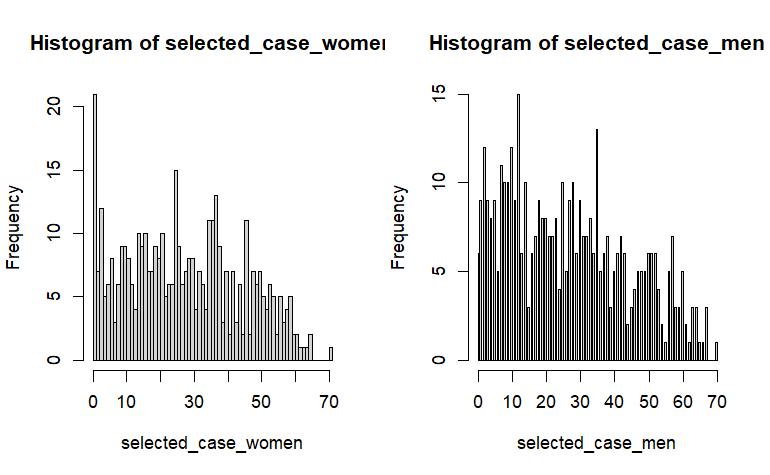

```r
layout(matrix(1:2, nrow = 1))
hist(selected_case_women, breaks = 101)
hist(selected_case_men, breaks = 101)
```

```r
# Put data into long format
age_struct_df <- tibble(
  age = c(selected_case_men, selected_case_women),
  sex = c(rep("Male", length(selected_case_men)),
          rep("Female", length(selected_case_women)))
)

# Bin ages into groups (5-year bins, adjust as needed)
age_struct_df <- age_struct_df |>
  mutate(age_group = cut(age, breaks = seq(0, 95, 5), right = FALSE))

# Summarize counts per age group and sex
age_struct_df_summary <- age_struct_df |>
  count(sex, age_group)

# For pyramid: make men negative
age_struct_df_summary <- age_struct_df_summary |>
  mutate(count = ifelse(sex == "Male", -n, n))
```

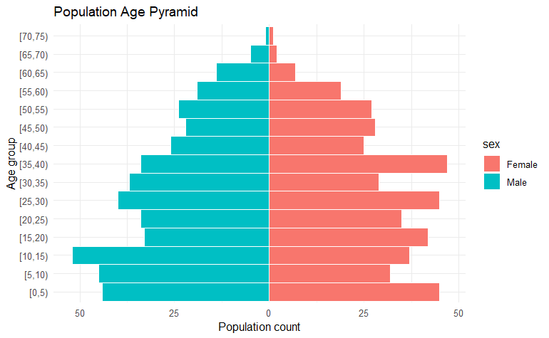

```r
ggplot(age_struct_df_summary, aes(x = age_group, y = count, fill = sex)) +
  geom_col(width = 1, color = "white") +
  coord_flip() +
  scale_y_continuous(labels = abs) +
  labs(
    title = "Population Age Pyramid",
    x = "Age group",
    y = "Population count"
  ) +
  theme_minimal()
```

Calculate the Peristera-Kostaki parameter ranges associated to survival:

```r
compute_param_envelope <- function(param_df, low=0.025, high=0.975){
  apply(param_df, 2, quantile, probs = c(low, high), na.rm=TRUE) %>%
    t() %>% as.data.frame() #%>% rename(lower = `2.5%`, upper = `97.5%`)
}
params_names <- gsub("-", ".", names(sobol_parameter_ranges)[7:19])
compute_param_envelope(endStates_patri %>% filter(survival != "extinction") %>% select(params_names))
```

|  | 2.5% | 97.5% |
| --- | --- | --- |
| cdmlt.level | 2.00000000 | 24.0000000 |
| c1.fert | 0.01293335 | 0.4875549 |
| mu.fert | 15.38067627 | 29.6193237 |
| sigma1.fert | 1.22840576 | 9.7671997 |
| sigma2.fert | 5.38067627 | 19.6193237 |
| c1.women | 0.02537842 | 0.9746216 |
| mu.women | 15.64666748 | 39.3655396 |
| sigma1.women | 1.48218994 | 19.5178101 |
| sigma2.women | 1.48218994 | 19.5178101 |
| c1.men | 0.02537842 | 0.9746216 |

[output cut: 3 more lines]

```r
params_indexes <- c(9, 12, 14:17, 20:27, 47:50)
param_names <- names(endStates_patri)[params_indexes]

endStates_patri_long <- endStates_patri %>%
  pivot_longer(cols = all_of(param_names)) %>%
  mutate(name = factor(name, levels = param_names))  # Preserve order
```

```r
source("library/bifurcationPlot.R")

plotName = paste0(plotDirectory, "sobol_bifurcationPlot_patri.png")

plotScale = 10

png(plotName,
    width = 150 * plotScale, height = 80 * plotScale)

ggplot(data = endStates_patri_long, aes(x = value, y = totalIndividuals)) +
  geom_point(alpha = 0.5) +
  geom_smooth(method = "glm") +
  facet_wrap(vars(name), ncol = 6, scales = "free_x") +
  theme(
    strip.text = element_text(size = 1.2 * plotScale)
  )

dev.off()
```

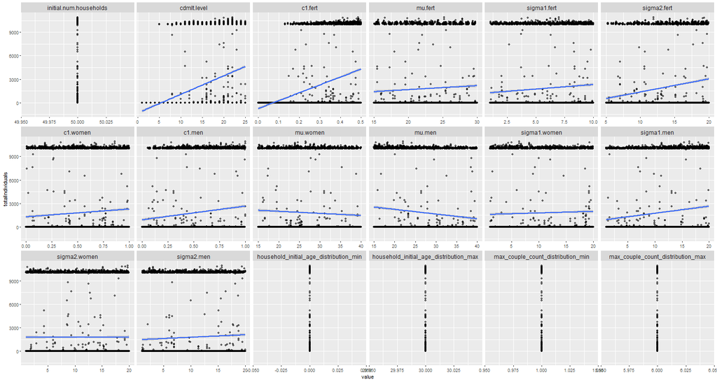

```r
knitr::include_graphics(plotName)
```

Train a Random Forest model to assess parameter importance:

```r
endStates_patri_for_rf <- endStates_patri[,c(params_indexes, 29)]

# Train Random Forest to predict simulation output
set.seed(123)
rf_model <- randomForest(totalIndividuals ~ ., data = endStates_patri_for_rf, importance = TRUE, ntree = 500)

# Print model summary
print(rf_model)
```

```
Call:
 randomForest(formula = totalIndividuals ~ ., data = endStates_patri_for_rf,      importance = TRUE, ntree = 500)
               Type of random forest: regression
                     Number of trees: 500
No. of variables tried at each split: 6

          Mean of squared residuals: 1062520
                    % Var explained: 92.8
```

Extract importance values and print as table:

```r
# Extract importance values
importance_values <- importance(rf_model)

# Convert to a data frame
importance_df <- data.frame(Parameter = rownames(importance_values),
                            MDA = importance_values[, 1],
                            MDG = importance_values[, 2])

# Print importance scores
print(importance_df)
```

|  | Parameter | MDA | MDG |
| --- | --- | --- | --- |
| initial.num.households | initial.num.households | 0.00000 | 0 |
| cdmlt.level | cdmlt.level | 195.01365 | 22908010042 |
| c1.fert | c1.fert | 180.07104 | 21048822181 |
| mu.fert | mu.fert | 35.36155 | 3441277400 |
| sigma1.fert | sigma1.fert | 44.78169 | 2733349310 |
| sigma2.fert | sigma2.fert | 80.83401 | 8593835322 |
| c1.women | c1.women | 39.17506 | 2950994152 |
| c1.men | c1.men | 69.07880 | 5848888507 |
| mu.women | mu.women | 41.14040 | 2303451798 |
| mu.men | mu.men | 46.60326 | 4201065065 |

[output cut: 8 more lines]

Plot feature importance colouring parameters by domain (general, mortality, fertility, nuptiality):

```r
source("library/variableImportancePlot.R")

plotName = paste0(plotDirectory, "sobol_variableImportancePlot_patri.png")

color_variable_map <- rev(c("#0000a2",
                        "#bc272d",
                        rep("#e9c716", 4),
                        rep("#50ad9f", 8),
                        rep("#0000a2", 4)
))

# png
png(filename = plotName, width = 129, height = 168, units="mm", res=1200)
variableImportancePlot(rf_model, plot_scale = 0.5, color_variable_map = color_variable_map, range_standardised = TRUE)
dev.off()
```

```r
knitr::include_graphics(plotName)
```

[figure not shown]

## Trajectories

> Run experiments in NetLogo Behaviour Space using average parameter values for parametric demographic models within the configurations with surviving population in the former experiment.

Loading simulation experiments’ end states:

```r
trajectories_v11 <- read.csv("simdata/v1.1/householdDemography v.1.1 - kinship tabu for new couples exp-trajectories-table.csv", skip = 6)
trajectories_v122 <- read.csv("simdata/v1.2.2/householdDemography v.1.2.2 - mortality regulated by density with weighted k and labour exp-trajectories-table.csv", skip = 6)
```

Process parameters in list format in NetLogo:

```r
extract_values_from_NetLogo_list <- function(char_vector) {
  # Remove brackets and split each string into two parts
  split_values <- gsub("\\[|\\]", "", char_vector) |>
    strsplit(" ")

  # Convert to numeric vectors
  first_values <- sapply(split_values, function(x) as.numeric(x[1]))
  second_values <- sapply(split_values, function(x) as.numeric(x[2]))

  # Return as a named list
  list(
    first = first_values,
    second = second_values
  )
}

household_initial_age_distribution_range_v11 <- extract_values_from_NetLogo_list(trajectories_v11$household.initial.age.distribution)
max_couple_count_distribution_range_v11 <- extract_values_from_NetLogo_list(trajectories_v11$max.couple.count.distribution)

household_initial_age_distribution_range_v122 <- extract_values_from_NetLogo_list(trajectories_v122$household.initial.age.distribution)
max_couple_count_distribution_range_v122 <- extract_values_from_NetLogo_list(trajectories_v122$max.couple.count.distribution)

trajectories_v11 <- cbind(
  trajectories_v11,
  household_initial_age_distribution_min = household_initial_age_distribution_range_v11[[1]],
  household_initial_age_distribution_max = household_initial_age_distribution_range_v11[[2]],
  max_couple_count_distribution_min = max_couple_count_distribution_range_v11[[1]],
  max_couple_count_distribution_max = max_couple_count_distribution_range_v11[[2]]
)

trajectories_v122 <- cbind(
  trajectories_v122,
  household_initial_age_distribution_min = household_initial_age_distribution_range_v122[[1]],
  household_initial_age_distribution_max = household_initial_age_distribution_range_v122[[2]],
  max_couple_count_distribution_min = max_couple_count_distribution_range_v122[[1]],
  max_couple_count_distribution_max = max_couple_count_distribution_range_v122[[2]]
)
```

```r
params_indexes <- c(3:21)
param_names <- names(trajectories_v11)[params_indexes]
params_v11 <- trajectories_v11 %>%
  select(all_of(param_names)) %>%
  distinct() %>%
  t %>%
  apply(1, unique)
params_v11
```

```
$cdmlt.level
[1] "10" "15" "20" " 5"

$coale.demeny.region
[1] "west"

$c1.fert
[1] "0.3"

$mu.fert
[1] "20"

$sigma1.fert
[1] "5"

$sigma2.fert
[1] "12"

$c1.women
[1] "0.5"

$mu.women
[1] "25"

$sigma1.women
[1] "10"

$sigma2.women
[1] "10"

$c1.men
[1] "0.5"

$mu.men
[1] "25"

$sigma1.men
[1] "10"

$sigma2.men
[1] "10"

$max.couple.count.distribution
[1] "1 6"

$household.initial.age.distribution
[1] "0 30"

$residence.rule
[1] "matrilocal-matrilineal"

$acceptable.kinship.degree.for.couples
[1] "9"

$initial.num.households
[1] "50"
```

```r
params_indexes <- c(3:21, 22:24)
param_names <- names(trajectories_v122)[params_indexes]
params_v122 <- trajectories_v122 %>%
  select(all_of(param_names)) %>%
  distinct() %>%
  t %>%
  apply(1, unique)
params_v122
```

```
$cdmlt.level
[1] "20" "15" " 5" "10"

$coale.demeny.region
[1] "west"

$c1.fert
[1] "0.5"

$mu.fert
[1] "20"

$sigma1.fert
[1] "5"

$sigma2.fert
[1] "12"

$c1.women
[1] "0.5"

$mu.women
[1] "25"

$sigma1.women
[1] "10"

$sigma2.women
[1] "10"

$c1.men
[1] "0.5"

$mu.men
[1] "25"

$sigma1.men
[1] "10"

$sigma2.men
```

[output cut: 10 more lines]

```

$acceptable.kinship.degree.for.couples
[1] "9"

$initial.num.households
[1] "25"

$par_carrying.capacity
[1] "5000"

$par_density.effect.scaling.factor
[1] "0.05"

$par_labour.demand.per.capita
[1] "0.6"
```

```r
plot_name <- file.path(plotDirectory, paste0("HouseholdDemography-trajectories_v11-v122.", plot_file_format))

if (plot_file_format == "png") {
  graphic_scale <- 1
  legend_text_rescale <- legend_key_rescale <- graphic_scale * -0.5
  axis_text_rescale <- axis_title_rescale <- graphic_scale * -0.5

  png(plot_name, width = graphic_scale * 1600, height = graphic_scale * 800, res = 300, pointsize = 4)
} else if (plot_file_format == "eps") {
  graphic_scale = 1.2
  # font_rescale = -0.2
  # axis_text_rescale = -0.1
  # margin_text_rescale = -0.5

  extrafont::loadfonts(device = "postscript")
  grDevices::cairo_ps(filename = plot_name ,
                      pointsize = 12,
                      width = graphic_scale * 8,
                      height = graphic_scale * 4,
                      onefile = FALSE,
                      family = "sans"
                      )
}

p1 <- ggplot(trajectories_v11[trajectories_v11$X.step. < 600,], aes(x = X.step., y = totalIndividuals, group = X.run.number., color = cdmlt.level)) +
  geom_line(linewidth = .1) +
  xlab("time (years)") +
  ylab("population (individuals)") +
  ylim(c(0, 7000)) +
  guides(color = "none") +
  theme_minimal() +
  theme(axis.title = element_text(size = 10 * (graphic_scale + axis_title_rescale)),
        axis.text = element_text(size = 10 * (graphic_scale + axis_text_rescale)))

p2 <- ggplot(trajectories_v122[trajectories_v122$X.step. < 600,], aes(x = X.step., y = totalIndividuals, group = X.run.number., color = cdmlt.level)) +
  geom_line(linewidth = .1) +
  geom_hline(yintercept = as.numeric(params_v122$par_carrying.capacity)) +
  xlab("time (years)") +
  ylab("") +
  ylim(c(0, 7000)) +
  guides(color = guide_legend(title="Coale-Demeny\nLife Table Level", override.aes = list(linewidth = 2), reverse = TRUE)) +
  theme_minimal() +
  theme(axis.title = element_text(size = 10 * (graphic_scale + axis_title_rescale)),
        axis.text = element_text(size = 10 * (graphic_scale + axis_text_rescale)),
        legend.title = element_text(size = 10 * (graphic_scale + legend_text_rescale)),
        legend.text = element_text(size = 10 * (graphic_scale + legend_text_rescale)),
        legend.key.width = unit(2 * (graphic_scale + legend_key_rescale), 'lines'),
        legend.key.height = unit(2 * (graphic_scale + legend_key_rescale), 'lines'))

p3 <- grid.arrange(p1, p2, ncol = 2, widths = c(4, 5.1))

dev.off()
```

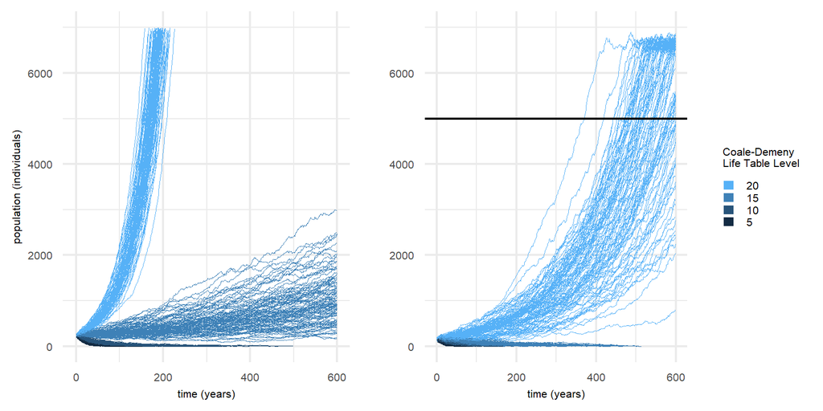

```r
knitr::include_graphics(plot_name)
```